# Lab 6

William

26 de agosto de 2018

## Exercícios

Para os exercícios a seguir:

1. efetue a regressão linear;
2. encontre os coeficientes de regressão;
3. plote o gráfico de dispersão e a reta de regressão;
4. plote o histograma dos resíduos;
5. plote o gráfico dos resíduos em função do preditor;
6. determine o valor esperado para os preditores especificados; e
7. utilize a função summary para verificar o valor de R².

### Andamento

| Item | Cars | $O_3 \times$ Rad | $O_3 \times$ Wind | Eleições |
| --- | --- | --- | --- | --- |
| 1 Regressão | Ok | Ok | Ok | Ok |
| 2 Coeficientes | Ok | Ok | Ok | - |
| 3 Dispersão e reta | Ok | Ok | Ok | Ok |
| 4 Hist. resíduos | Ok | Ok | Ok- | Ok |
| 5 Resíduos x $x$ | Ok | Ok | Ok | Ok |
| 6 Valores | Ok | Ok | Ok | Não há |
| 7 summary -> R² | Ok | Ok | Ok | - |

## Exercício 1 - cars

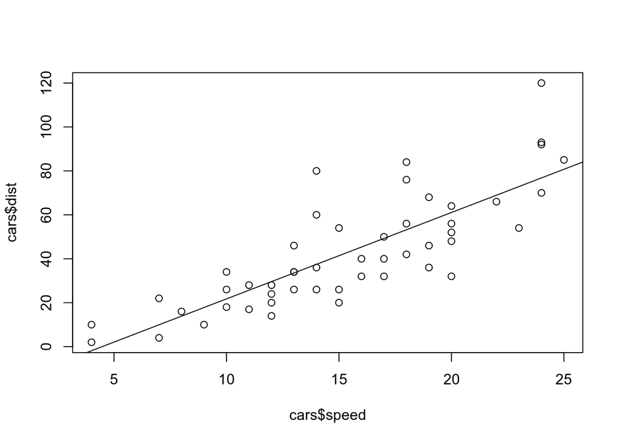

Os coeficientes são: $\beta_0$ == -17.5790949 e $\beta_1$ == 3.9324088 e os valores previstos estão na tabela abaixo:

```
##         5        10        14        23         3
##  2.082949 21.744993 37.474628 72.866307 -5.781869
```

### Análise dos resíduos

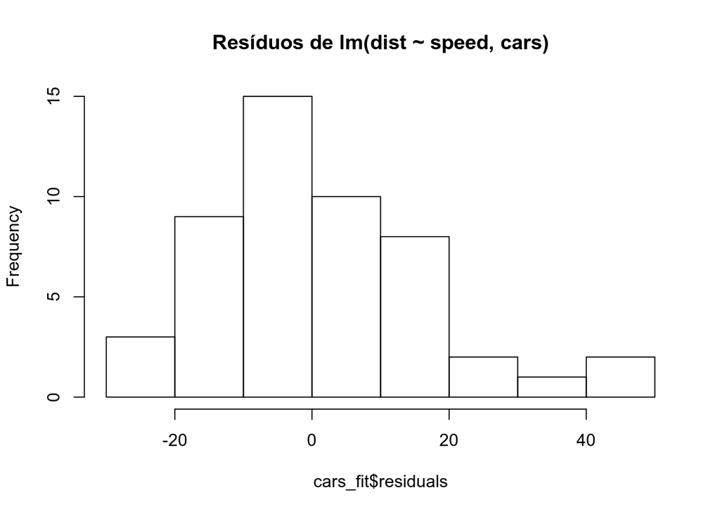

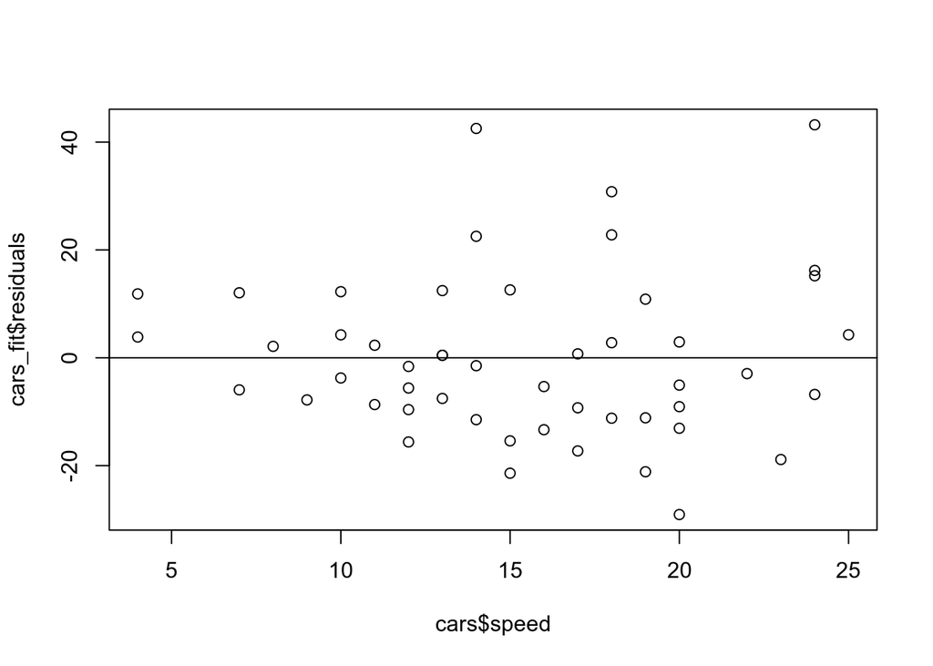

```
##
## Call:
## lm(formula = dist ~ speed, data = cars)
##
## Residuals:
##     Min      1Q  Median      3Q     Max
## -29.069  -9.525  -2.272   9.215  43.201
##
## Coefficients:
##             Estimate Std. Error t value Pr(>|t|)
## (Intercept) -17.5791     6.7584  -2.601   0.0123 *
## speed         3.9324     0.4155   9.464 1.49e-12 ***
## ---
## Signif. codes:  0 '***' 0.001 '**' 0.01 '*' 0.05 '.' 0.1 ' ' 1
##
## Residual standard error: 15.38 on 48 degrees of freedom
## Multiple R-squared:  0.6511, Adjusted R-squared:  0.6438
## F-statistic: 89.57 on 1 and 48 DF,  p-value: 1.49e-12
```

O valor de $R^2$ é 0.6510794 e o $R^2$ ajustado é 0.6438102, o que pode ser interpretado como sendo a velocidade no momento da frenagem responsável por explicar 64.3810201% da distância percorrida após esse ato.

## Exercício 2 - `airquality`

Verifique, por meio da regressão linear, a variação da *concentração de Ozônio* em função da *radiação solar*. **Estime** a concentração de Ozônio esperada para os seguintes níveis de radiação (lang): 10, 100, 200, 300.

Verifique, também, a variação da **concentração de Ozônio** em função da **velocidade do vento**. Estime a concentração de Ozônio esperada para as seguintes velocidades do vento (mph): 1.5, 3.7, 10, 15.3, 22

### Ozônio em função da radiação solar

Os coeficientes são: $\beta_0$ == 18.5987278 e $\beta_1$ == 0.1271653 e os valores previstos estão na tabela abaixo:

```
##       10      100      200      300
## 19.87038 31.31525 44.03178 56.74831
```

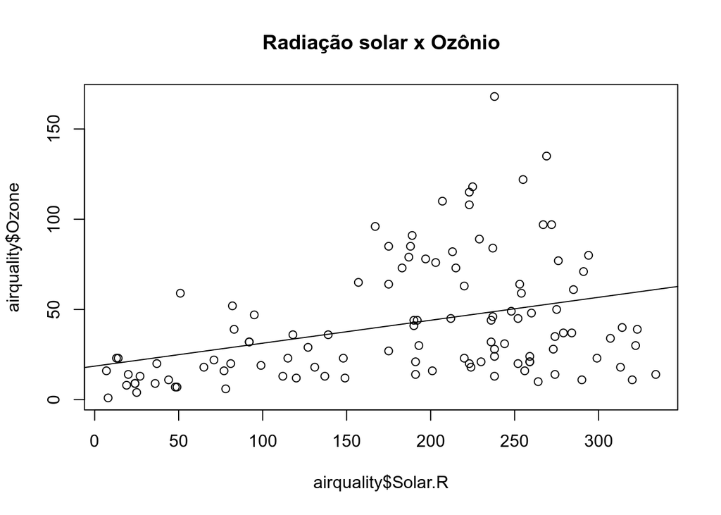

#### Análise dos resíduos

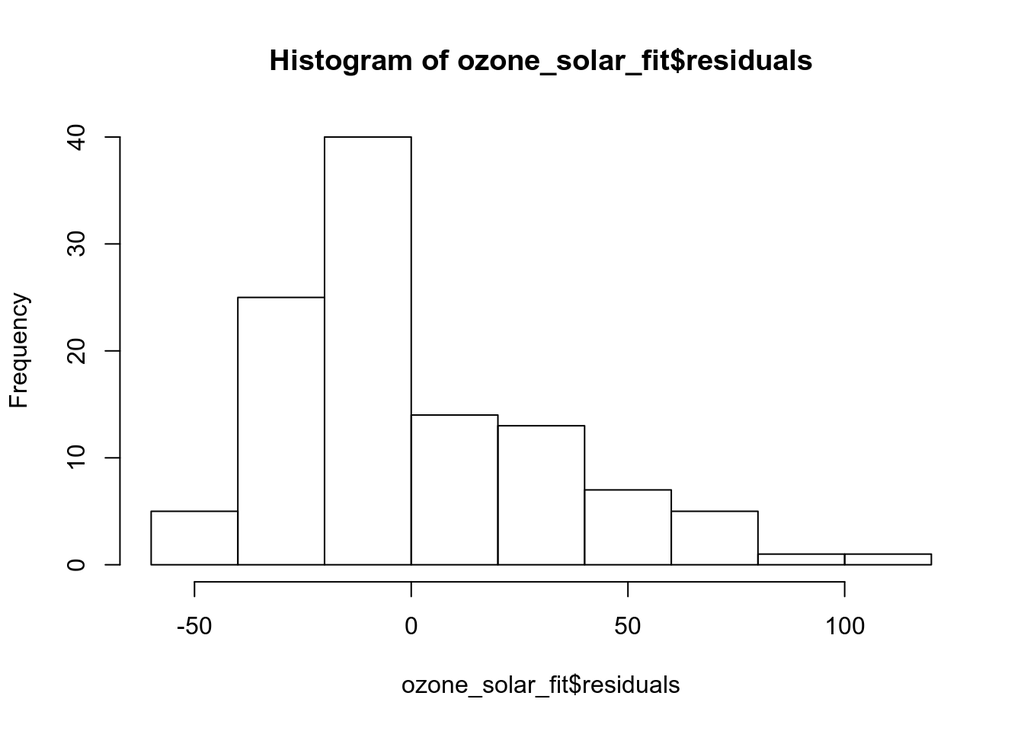

```r
hist(ozone_solar_fit$residuals)
```

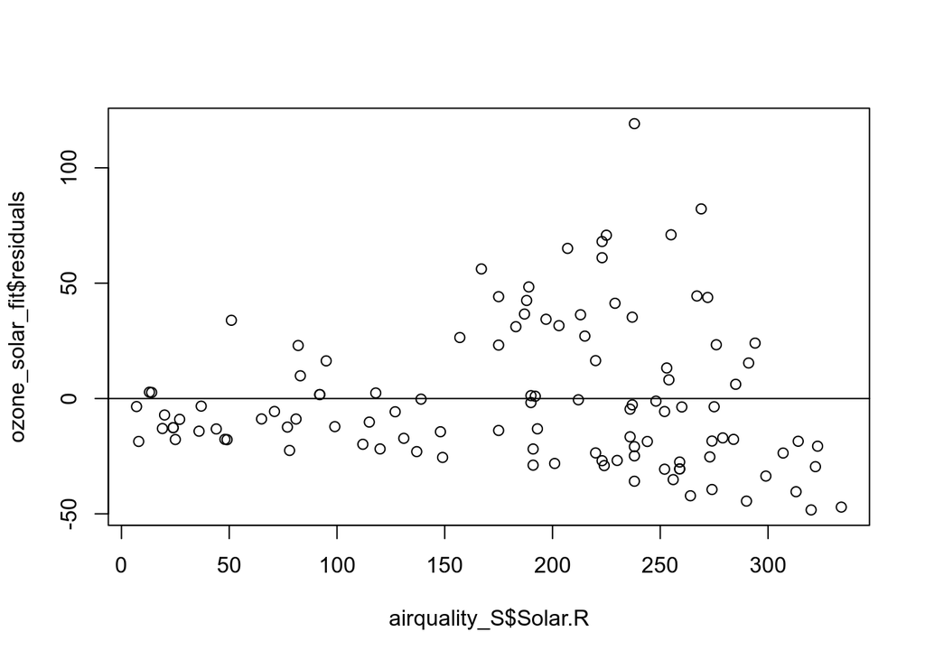

```r
plot(x=airquality_S$Solar.R, y=ozone_solar_fit$residuals)
abline(0,0)
```

```r
ozone_solar_fit_summary = summary(ozone_solar_fit)
```

O valor de $R^2$ é 0.1213419 e o $R^2$ ajustado é 0.1132809, o que pode ser interpretado como sendo a radiação solar responsável por explicar 11.3280852% da concenração de Ozônio. Contudo, o gráfico de dispersão dos resíduos em função do preditor levanta a suspeita de falta de homocedasticidade, o que compromete o uso de um modelo linear nesse caso.

### Ozônio em função da velocidade do vento

```r
airquality_S = airquality[complete.cases(airquality),]
ozone_wind_fit = lm(airquality_S$Ozone ~ airquality_S$Wind)
ozone_wind_values = c(1.5, 3.7, 10, 15.3, 22)

print("Previsão de valores ausentes")
```

```
## [1] "Previsão de valores ausentes"
```

```r
print(simple_predict(ozone_wind_fit, ozone_wind_values))
```

```
##       1.5       3.7        10      15.3        22
##  90.44808  77.84473  41.75331  11.39068 -26.99226
```

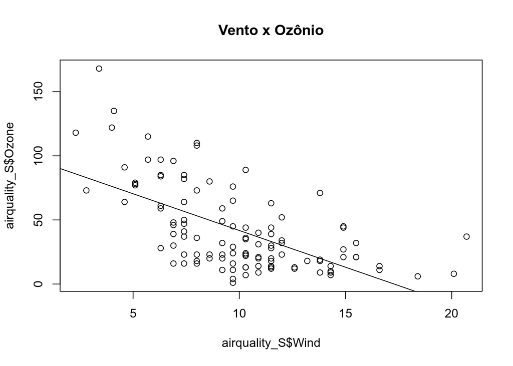

```r
# airq_S = airquality
plot(airquality_S$Wind, airquality_S$Ozone, main="Vento x Ozônio")
abline(ozone_wind_fit)
```

#### Análise de resíduos

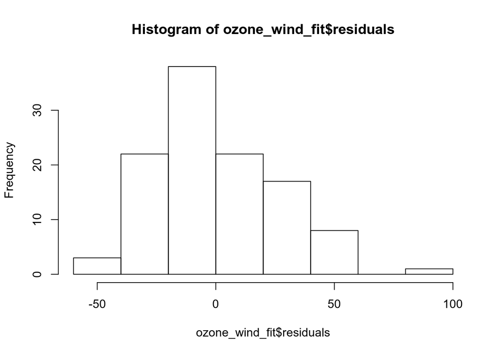

```r
hist(ozone_wind_fit$residuals)
```

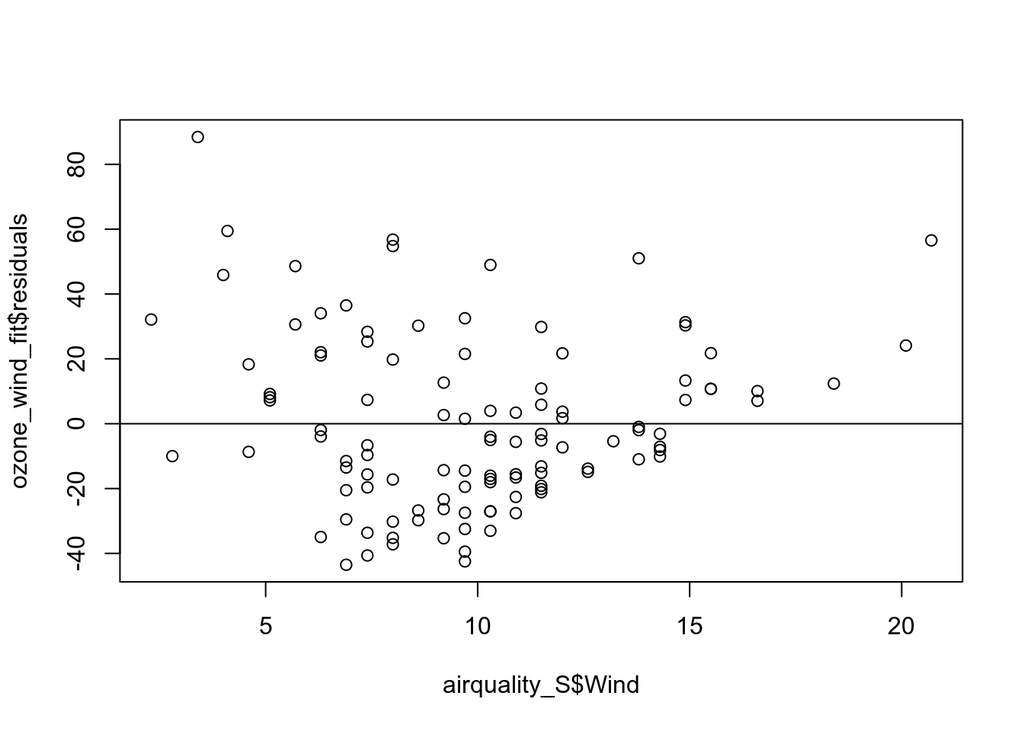

```r
plot(x=airquality_S$Wind, y=ozone_wind_fit$residuals)
abline(0,0)
```

```r
ozone_wind_fit_summary = summary(ozone_wind_fit)
```

O valor de $R^2$ é 0.3751521 e o $R^2$ ajustado é 0.3694195, o que pode ser interpretado como sendo a velocidade do vento responsável por explicar 36.9419506% da concenração de Ozônio. Contudo, o gráfico de dispersão dos resíduos em função do preditor levanta a suspeita de falta de homocedasticidade, o que compromete o uso de um modelo linear nesse caso.

## Exercício 3 - Eleições

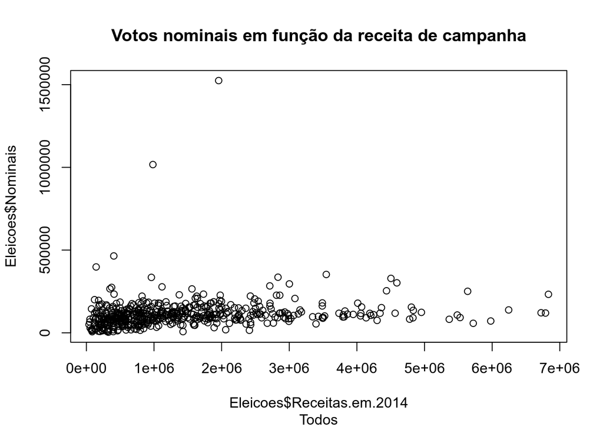

```r
Eleicoes = read.csv("Eleicoes2014_utf8.csv", encoding = "utf-8", sep=";", header = T)
plot(x=Eleicoes$Receitas.em.2014, y=Eleicoes$Nominais,
     main = "Votos nominais em função da receita de campanha", sub = "Todos")
```

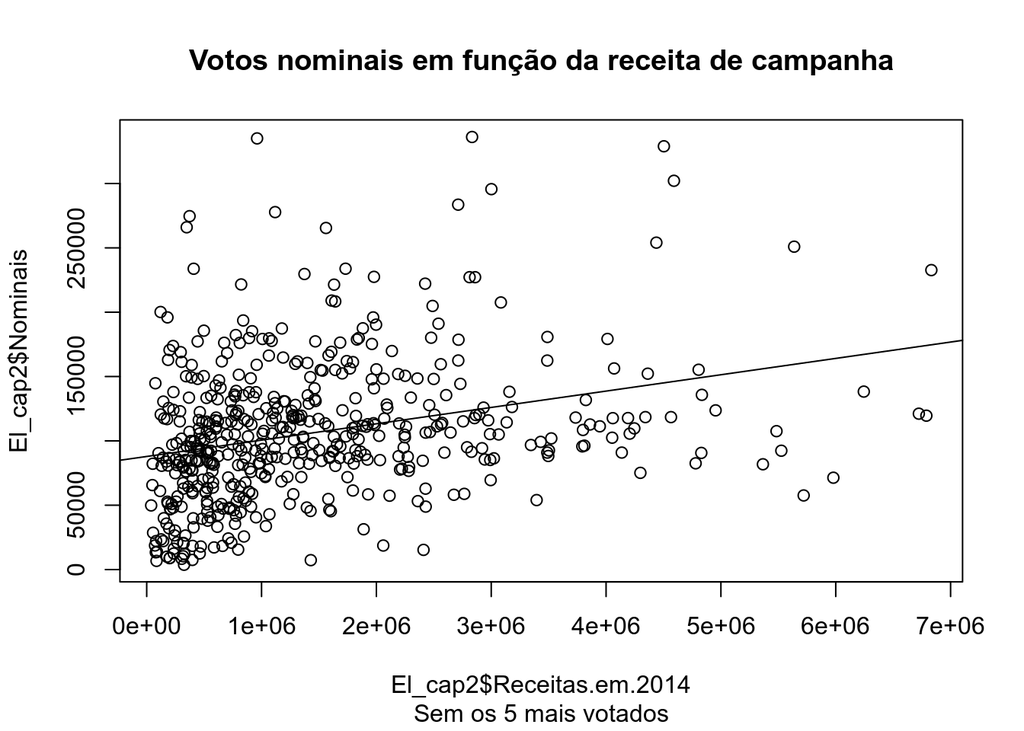

```r
El_cap2 = Eleicoes[Eleicoes$Nominais<350000,]  # Descartar outliers
Elm_cap2 = lm(El_cap2$Nominais ~ El_cap2$Receitas.em.2014)
plot(x=El_cap2$Receitas.em.2014, y=El_cap2$Nominais,
     main = "Votos nominais em função da receita de campanha",
     sub = "Sem os 5 mais votados")
abline(Elm_cap2)
```

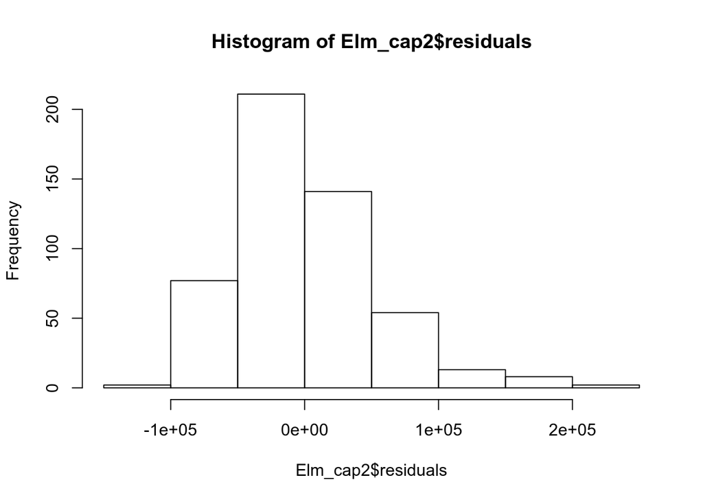

```r
hist(Elm_cap2$residuals)
```

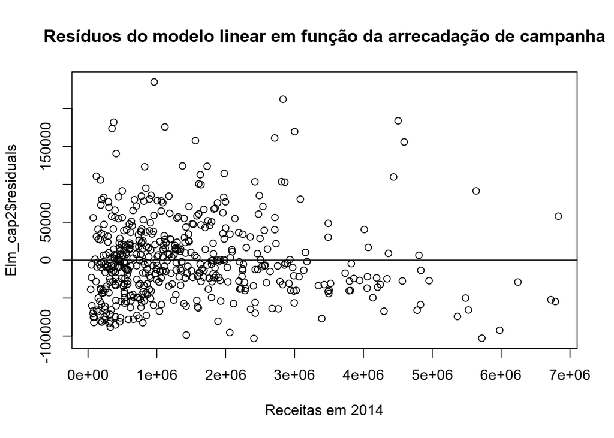

```r
plot(x=El_cap2$Receitas.em.2014, y=Elm_cap2$residuals,
     main = "Resíduos do modelo linear em função da arrecadação de campanha",
     xlab = "Receitas em 2014")
abline(0,0)
```

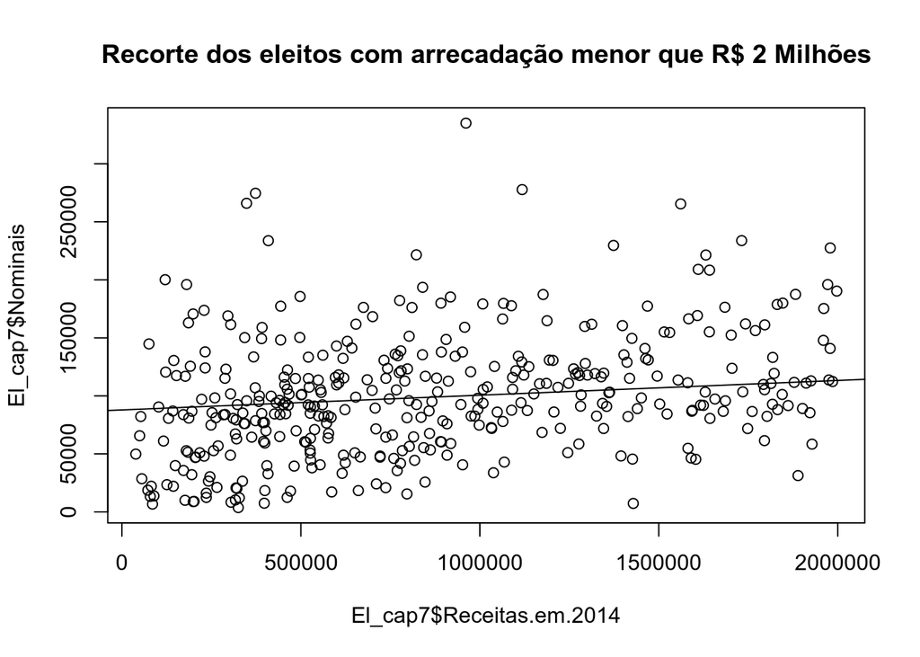

```r
El_cap7 = El_cap2[El_cap2$Receitas.em.2014 < 2e+06,]
plot(x=El_cap7$Receitas.em.2014, y=El_cap7$Nominais,
     main = "Recorte dos eleitos com arrecadação menor que R$ 2 Milhões")
abline(Elm_cap2)
```

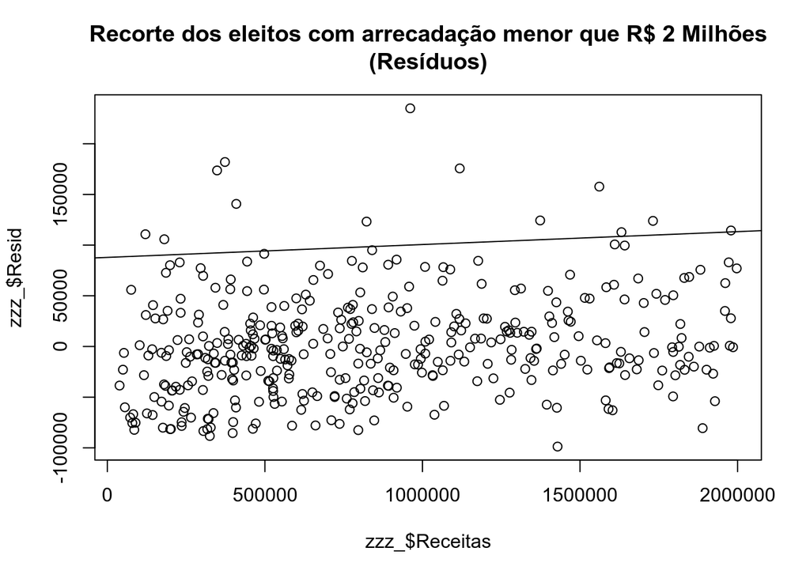

```r
zzz = data.frame(Receitas = El_cap2$Receitas.em.2014, Resid = Elm_cap2$residuals)
zzz_ = zzz[zzz$Receitas < 2e+06,]
plot(x=zzz_$Receitas, y=zzz_$Resid,
     main = "Recorte dos eleitos com arrecadação menor que R$ 2 Milhões\n(Resíduos)")
abline(Elm_cap2)
```

```r
SumEl = summary(Elm_cap2)
```

O valor de $R^2$ é 0.0863172 e o $R^2$ ajustado é 0.0845115, o que pode ser interpretado como sendo a arrecadação de campanha responsável por explicar 8.4511541% da quantidade de votos nominais recebidos.

## Exercício 4 - Bandas de confiança e de predição

```r
source("lmIC.R")
```

### Cars

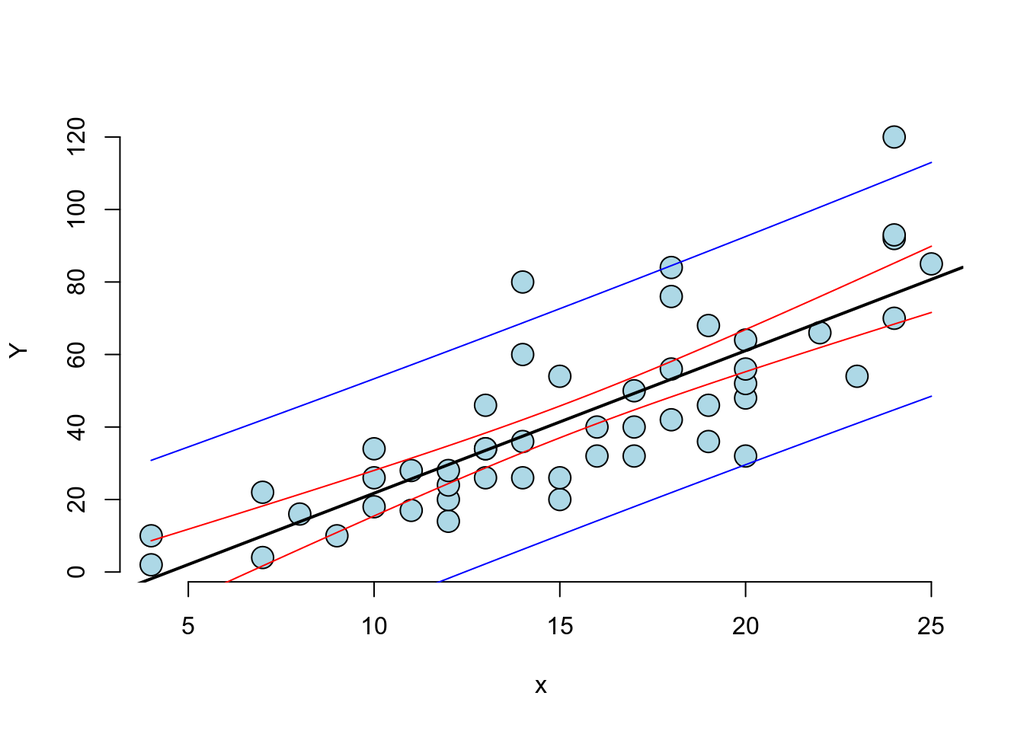

```
##       esperado      Icmin     ICmax
## [1,]  2.082949 -30.333587  34.49948
## [2,] 21.744993  -9.809601  53.29959
## [3,] 37.474628   6.222305  68.72695
## [4,] 72.866307  40.996976 104.73564
## [5,] -5.781869 -38.685654  27.12192
```

```r
lmIC(cars$speed, cars$dist, vx=cars_values)
```

### Air Quality

#### Ozônio em função da radiação solar

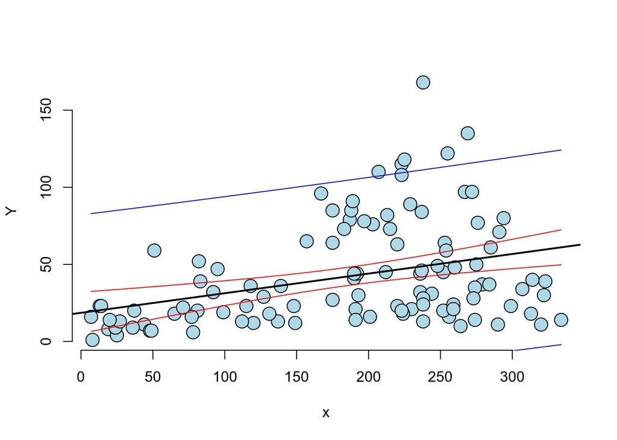

```
##      esperado      Icmin     ICmax
## [1,] 19.87038 -43.537910  83.27867
## [2,] 31.31525 -31.310729  93.94124
## [3,] 44.03178 -18.359252 106.42282
## [4,] 56.74831  -6.082164 119.57878
```

```r
lmIC(airquality_S$Solar.R, airquality_S$Ozone, vx=ozone_solar_values)
```

#### Ozônio em função da velocidade do vento

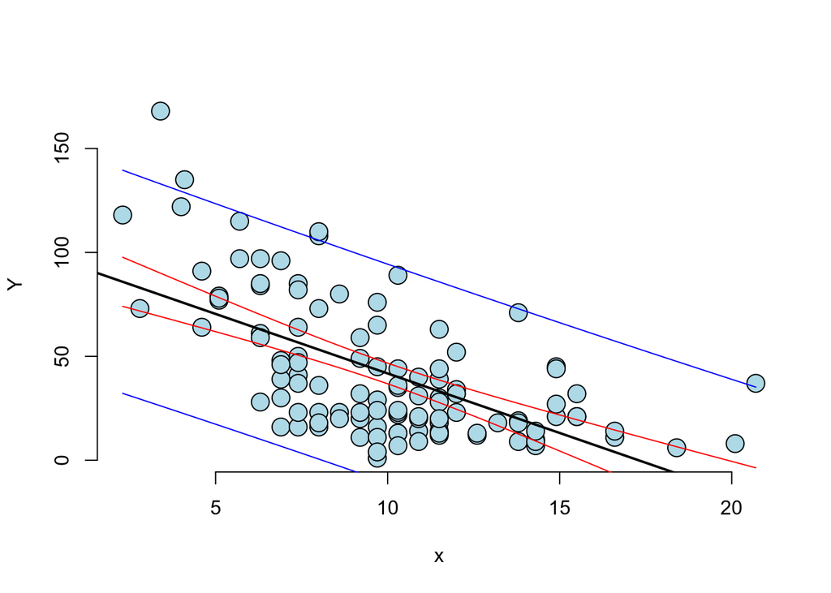

```
##       esperado     Icmin     ICmax
## [1,]  90.44808  36.52377 144.37240
## [2,]  77.84473  24.51357 131.17589
## [3,]  41.75331 -10.85394  94.36055
## [4,]  11.39068 -41.75176  64.53313
## [5,] -26.99226 -82.25574  28.27123
```

```r
lmIC(airquality_S$Wind, airquality_S$Ozone, vx=ozone_wind_values)
```

### Eleições: Quantidade de votos nominais em função da arrecadação de campanha (sem *outliers*)

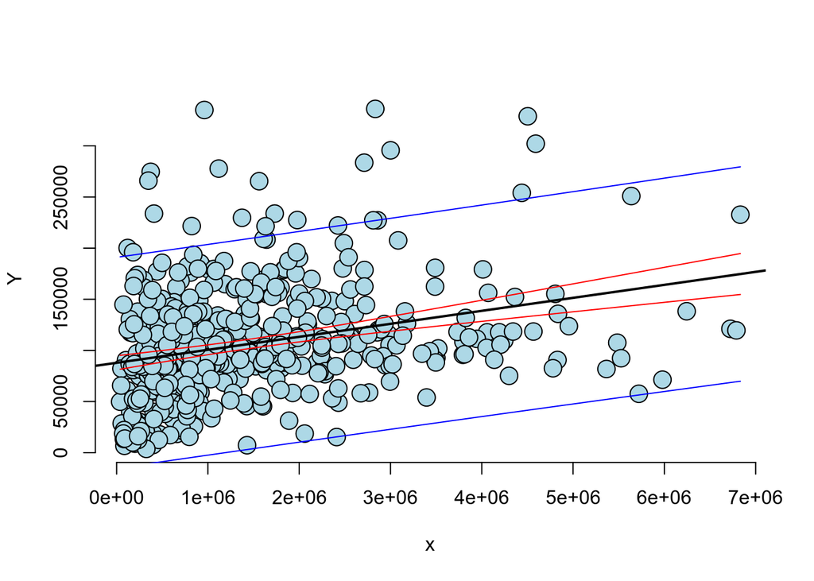

```r
lmIC(El_cap2$Receitas.em.2014, El_cap2$Nominais)
```